# Initial Exploration of the P/NBD Model

In this workbook we introduce the various different BTYD models, starting with a discussion of the underlying theory.

# 1 Background Theory

Before we start working on fitting and using the various Buy-Till-You-Die models, we first need to discuss the basic underlying theory and model.

In this model, we assume a customer becomes ‘alive’ to the business at the first purchase and then makes purchases stochastically but at a steady-rate for a period of time, and then ‘dies’ - i.e. becomes inactive to the business - hence the use of “Buy-Till-You-Die”.

Thus, at a high level these models decompose into modelling the transaction events using distributions such as the Poisson or Negative Binomial, and then modelling the ‘dropout’ process using some other method.

These models require only two pieces of information about each customer’s purchasing history: the “recency” (when the last transaction occurred) and “frequency” (the count of transactions made by that customer in a specified time period).

The notation used to represent this information is

$$X = (x, \, t_x, \, T),$$
where

From this summary data we can fit most BTYD models.

## 1.1 BTYD Models

There are a number of different statistical approaches to building BTYD models - relying on a number of different assumptions about how the various recency, frequency and monetary values are modelled.

We now discuss a number of different ways of modelling this.

### 1.1.1 Beta-Geometric/Negative-Binomial Distribution (BG/NBD) Model

This model relies on a number of base assumptions:

1. While active, the number of transactions made by a customer follows a Poisson process with transaction rate $\lambda$.
2. Heterogeneity in $\lambda$ follows a Gamma distribution $\Gamma(\lambda \, | \, \alpha, r)$ with parameters shape $r$ and rate $\alpha$.
3. After any transaction, a customer becomes inactive with probability $p$.
4. Heterogeneity in $p$ follows a Beta distribution $B(p \, | \, a, b)$ with shape parameters $a$ and $b$.
5. The transaction rate $\lambda$ and the dropout probability $p$ vary independently across customers.

Note that it follows from the above assumptions that the probability of a customer being ‘alive’ after any transaction is given by the Geometric distribution, and hence the Beta-Geometric in the name.

To put this into more formal mathematical notation, we have:

$$\begin{eqnarray*}
\lambda &\sim& \Gamma(\alpha, r), \\
P(\text{alive}, k) &\sim& \text{Geometric}(p, k), \\
p &\sim& \text{Beta}(a, b)
\end{eqnarray*}$$

### 1.1.2 Pareto/Negative-Binomial Distribution (P/NBD) Model

Similar to the BG/NBD model, the P/NBD model relies on five assumptions:

1. While active, the number of transactions made by a customer follows a Poisson process with transaction rate $\lambda$.
2. Heterogeneity in $\lambda$ follows a Gamma distribution $\Gamma(\lambda \, | \, \alpha, r)$ with shape $r$ and rate $\alpha$.
3. Each customer has an unobserved ‘lifetime’ of length $\tau$. This point at which the customer becomes inactive is distributed as an exponential with dropout rate $\mu$.
4. Heterogeneity in dropout rates across customers follows a Gamma distribution $\Gamma(\mu \, | \, s, \beta)$ with shape parameter $s$ and rate parameter $\beta$.
5. The transaction rate $\lambda$ and the dropout rate $\mu$ vary independently across customers.

As before, we express this in mathematical notation as:

$$\begin{eqnarray*}
\lambda &\sim& \Gamma(\alpha, r), \\
\mu &\sim& \Gamma(s, \beta), \\
\tau &\sim& \text{Exponential}(\mu)
\end{eqnarray*}$$

### 1.1.3 Gamma/Gamma Spending Model

The final piece of this approach is to construct a spending model for the transactions. Similar to transaction rates, spending patterns are often skewed, so a Gamma distribution is used.

For the Gamma/Gamma model, we use the following assumptions:

1. Each transaction amount, $v_i$, is distributed according to a Gamma distribution $\Gamma(v_i \, | \, p, \nu)$ with shape parameter $p$ and rate parameter $\nu$.
2. Heterogeneity in $nu$ follows a Gamma distribution $\Gamma(\nu \, | \, q, \gamma)$

In mathematical notation, we have:

# 2 Fit Synthetic Data Model

We take our transaction data and transform the data into a format amenable for the BTYD models.

We first ensure that all transactions on the same day or combined into a single transaction, and then convert this data into the $(x, t_x, T)$ triplet-format.

To mimic the training / test split to help validate real-world models, we do the same thing here.

```r
training_data_date <- as.Date("2011-03-31")
```

We also wish to load the generated data.

```r
customer_basic_simparams_tbl <- read_rds("data/customer_basic_simparams_tbl.rds")
customer_basic_simparams_tbl %>% glimpse()
```

```
## Rows: 5,852
## Columns: 9
## $ customer_id     <chr> "12490", "12533", "12682", "12758", "12836", "12913", …
## $ cohort_qtr      <chr> "2009 Q4", "2009 Q4", "2009 Q4", "2009 Q4", "2009 Q4",…
## $ cohort_ym       <chr> "2009 12", "2009 12", "2009 12", "2009 12", "2009 12",…
## $ first_tnx_date  <date> 2009-12-01, 2009-12-01, 2009-12-01, 2009-12-01, 2009-…
## $ customer_mu     <dbl> 0.193929578, 0.018041910, 0.053443286, 0.002396523, 0.…
## $ customer_tau    <dbl> 0.5266278, 75.2259954, 14.2815124, 112.1151678, 15.836…
## $ customer_lambda <dbl> 0.13543393, 0.54140899, 0.58536864, 0.07433727, 0.0149…
## $ customer_nu     <dbl> 0.655802984, 1.218495551, 0.826828489, 0.569981858, 0.…
## $ customer_p      <dbl> 100, 100, 100, 100, 100, 100, 100, 100, 100, 100, 100,…
```

```r
customer_basic_transactions_tbl <- read_rds("data/customer_basic_transactions_tbl.rds")
customer_basic_transactions_tbl %>% glimpse()
```

```
## Rows: 44,872
## Columns: 4
## $ customer_id   <chr> "15719", "13585", "17519", "15712", "16321", "15362", "1…
## $ tnx_timestamp <dttm> 2009-12-01 00:19:10, 2009-12-01 00:48:16, 2009-12-01 00…
## $ invoice_id    <chr> "20091201_0001", "20091201_0002", "20091201_0003", "2009…
## $ tnx_amount    <dbl> 323.91, 57.12, 388.42, 49.98, 50.91, 91.66, 90.06, 43.75…
```

```r
customer_cohort_data_tbl <- read_rds("data/customer_cohort_tbl.rds")
customer_cohort_data_tbl %>% glimpse()
```

```
## Rows: 5,852
## Columns: 5
## $ customer_id     <chr> "12346", "12347", "12348", "12349", "12350", "12351", …
## $ cohort_qtr      <yearqtr> 2010 Q1, 2010 Q4, 2010 Q3, 2010 Q2, 2011 Q1, 2010 …
## $ cohort_ym       <chr> "2010 03", "2010 10", "2010 09", "2010 04", "2011 02",…
## $ first_tnx_date  <date> 2010-03-02, 2010-10-31, 2010-09-27, 2010-04-29, 2011-…
## $ total_tnx_count <int> 3, 8, 5, 3, 1, 1, 9, 2, 1, 2, 6, 2, 5, 10, 6, 4, 10, 2…
```

We now convert the transaction data into the CBS format as an input the BTYD models.

```r
calculate_transaction_cbs_data <- function(tnx_data_tbl, last_date) {
  cbs_data_tbl <- tnx_data_tbl %>%
    filter(tnx_timestamp <= last_date) %>%
    group_by(customer_id) %>%
    summarise(
      .groups = "drop",

      first_tnx_date = min(tnx_timestamp),
      last_tnx_date  = max(tnx_timestamp),

      x     = n() - 1,
      t_x   = difftime(last_tnx_date, first_tnx_date, units = "weeks") %>% as.numeric(),
      T_cal = difftime(last_date,     first_tnx_date, units = "weeks") %>% as.numeric()
      )

  return(cbs_data_tbl)
}
```

We now combine all this data to construct our CLV input data.

```r
customer_basic_cbs_tbl <- customer_basic_transactions_tbl %>%
  calculate_transaction_cbs_data(
    last_date = training_data_date
    ) %>%
  filter(
    first_tnx_date <= training_data_date,
    x > 0
    )

customer_basic_cbs_tbl %>% glimpse()
```

```
## Rows: 3,175
## Columns: 6
## $ customer_id    <chr> "12346", "12347", "12350", "12356", "12357", "12359", "…
## $ first_tnx_date <dttm> 2010-03-02 00:01:53, 2010-10-31 10:13:44, 2011-02-02 1…
## $ last_tnx_date  <dttm> 2010-12-02 01:53:06, 2010-12-15 06:49:04, 2011-03-25 0…
## $ x              <dbl> 12, 1, 8, 1, 5, 13, 2, 3, 13, 5, 23, 3, 3, 8, 9, 5, 3, …
## $ t_x            <dbl> 39.296747, 6.408267, 7.255974, 18.353767, 1.699002, 65.…
## $ T_cal          <dbl> 56.285526, 21.510542, 8.071357, 24.420176, 19.236380, 6…
```

We now write that CBS data to disk for later use.

```r
customer_basic_cbs_tbl %>% write_rds("data/customer_basic_cbs_tbl.rds")
```

## 2.1 Construct Fixed Hyper-parameter Model

```r
pnbd_basic_fixed_stanmodel <- cmdstan_model(
  "stan_code/clv_pnbd_fixed.stan",
  include_paths = "stan_code/",
  pedantic      =  TRUE,
  dir           = "stan_models/"
  )
```

```r
stan_data_lst <- customer_basic_cbs_tbl %>%
  select(-first_tnx_date, -last_tnx_date) %>%
  compose_data(
    r     =  1,
    alpha =  3,

    s     =  1,
    beta  = 10,
    )

pnbd_basic_fixed_stanfit <- pnbd_basic_fixed_stanmodel$sample(
  data          =  stan_data_lst,
  chains        =              4,
  iter_warmup   =           1000,
  iter_sampling =           1000,
  seed          =            421
  )
```

```
## Running MCMC with 4 parallel chains...
##
## Chain 1 Iteration:    1 / 2000 [  0%]  (Warmup)
## Chain 2 Iteration:    1 / 2000 [  0%]  (Warmup)
## Chain 3 Iteration:    1 / 2000 [  0%]  (Warmup)
## Chain 4 Iteration:    1 / 2000 [  0%]  (Warmup)
## Chain 1 Iteration:  100 / 2000 [  5%]  (Warmup)
## Chain 2 Iteration:  100 / 2000 [  5%]  (Warmup)
## Chain 3 Iteration:  100 / 2000 [  5%]  (Warmup)
## Chain 4 Iteration:  100 / 2000 [  5%]  (Warmup)
## Chain 3 Iteration:  200 / 2000 [ 10%]  (Warmup)
## Chain 2 Iteration:  200 / 2000 [ 10%]  (Warmup)
## Chain 4 Iteration:  200 / 2000 [ 10%]  (Warmup)
## Chain 1 Iteration:  200 / 2000 [ 10%]  (Warmup)
## Chain 3 Iteration:  300 / 2000 [ 15%]  (Warmup)
## Chain 4 Iteration:  300 / 2000 [ 15%]  (Warmup)
## Chain 2 Iteration:  300 / 2000 [ 15%]  (Warmup)
## Chain 1 Iteration:  300 / 2000 [ 15%]  (Warmup)
## Chain 4 Iteration:  400 / 2000 [ 20%]  (Warmup)
## Chain 3 Iteration:  400 / 2000 [ 20%]  (Warmup)
## Chain 1 Iteration:  400 / 2000 [ 20%]  (Warmup)
## Chain 2 Iteration:  400 / 2000 [ 20%]  (Warmup)
## Chain 4 Iteration:  500 / 2000 [ 25%]  (Warmup)
## Chain 3 Iteration:  500 / 2000 [ 25%]  (Warmup)
## Chain 1 Iteration:  500 / 2000 [ 25%]  (Warmup)
## Chain 2 Iteration:  500 / 2000 [ 25%]  (Warmup)
## Chain 4 Iteration:  600 / 2000 [ 30%]  (Warmup)
## Chain 2 Iteration:  600 / 2000 [ 30%]  (Warmup)
## Chain 1 Iteration:  600 / 2000 [ 30%]  (Warmup)
## Chain 3 Iteration:  600 / 2000 [ 30%]  (Warmup)
## Chain 4 Iteration:  700 / 2000 [ 35%]  (Warmup)
## Chain 2 Iteration:  700 / 2000 [ 35%]  (Warmup)
## Chain 1 Iteration:  700 / 2000 [ 35%]  (Warmup)
## Chain 3 Iteration:  700 / 2000 [ 35%]  (Warmup)
## Chain 4 Iteration:  800 / 2000 [ 40%]  (Warmup)
## Chain 2 Iteration:  800 / 2000 [ 40%]  (Warmup)
## Chain 1 Iteration:  800 / 2000 [ 40%]  (Warmup)
## Chain 3 Iteration:  800 / 2000 [ 40%]  (Warmup)
## Chain 4 Iteration:  900 / 2000 [ 45%]  (Warmup)
## Chain 2 Iteration:  900 / 2000 [ 45%]  (Warmup)
```

[output cut: 43 more lines]

```
## Chain 2 Iteration: 1900 / 2000 [ 95%]  (Sampling)
## Chain 1 Iteration: 1900 / 2000 [ 95%]  (Sampling)
## Chain 3 Iteration: 1900 / 2000 [ 95%]  (Sampling)
## Chain 4 Iteration: 2000 / 2000 [100%]  (Sampling)
## Chain 4 finished in 153.3 seconds.
## Chain 2 Iteration: 2000 / 2000 [100%]  (Sampling)
## Chain 2 finished in 154.1 seconds.
## Chain 1 Iteration: 2000 / 2000 [100%]  (Sampling)
## Chain 1 finished in 154.6 seconds.
## Chain 3 Iteration: 2000 / 2000 [100%]  (Sampling)
## Chain 3 finished in 154.9 seconds.
##
## All 4 chains finished successfully.
## Mean chain execution time: 154.2 seconds.
## Total execution time: 155.6 seconds.
```

We first want to check the HMC diagnostics.

```r
pnbd_basic_fixed_stanfit$cmdstan_diagnose()
```

```
## Processing csv files: /tmp/Rtmpej5ofO/clv_pnbd_fixed-202112141550-1-8b9b08.csv, /tmp/Rtmpej5ofO/clv_pnbd_fixed-202112141550-2-8b9b08.csv, /tmp/Rtmpej5ofO/clv_pnbd_fixed-202112141550-3-8b9b08.csv, /tmp/Rtmpej5ofO/clv_pnbd_fixed-202112141550-4-8b9b08.csv
##
## Checking sampler transitions treedepth.
## Treedepth satisfactory for all transitions.
##
## Checking sampler transitions for divergences.
## No divergent transitions found.
##
## Checking E-BFMI - sampler transitions HMC potential energy.
## E-BFMI satisfactory.
##
## Effective sample size satisfactory.
##
## Split R-hat values satisfactory all parameters.
##
## Processing complete, no problems detected.
```

```r
pnbd_basic_fixed_stanfit$save_output_files(
  dir      = "stan_models",
  basename = "pnbd_basic_fixed"
  )
```

We use the functionality given by `tidybayes` to extract the posterior distribution of the parameters.

```r
customer_basic_pnbd_fixed_draws <- pnbd_basic_fixed_stanfit$draws()

customer_basic_pnbd_fixed_posterior_tbl <- customer_basic_pnbd_fixed_draws %>%
  recover_types(customer_basic_cbs_tbl) %>%
  spread_draws(mu[customer_id], lambda[customer_id]) %>%
  ungroup()

customer_basic_pnbd_fixed_posterior_tbl %>% glimpse()
```

```
## Rows: 12,700,000
## Columns: 6
## $ customer_id <chr> "12346", "12346", "12346", "12346", "12346", "12346", "123…
## $ mu          <dbl> 0.00226439, 0.04375680, 0.03413170, 0.05733460, 0.01861390…
## $ .chain      <int> 1, 1, 1, 1, 1, 1, 1, 1, 1, 1, 1, 1, 1, 1, 1, 1, 1, 1, 1, 1…
## $ .iteration  <int> 1, 2, 3, 4, 5, 6, 7, 8, 9, 10, 11, 12, 13, 14, 15, 16, 17,…
## $ .draw       <int> 1, 2, 3, 4, 5, 6, 7, 8, 9, 10, 11, 12, 13, 14, 15, 16, 17,…
## $ lambda      <dbl> 0.170748, 0.158926, 0.199928, 0.166071, 0.279805, 0.351649…
```

```r
customer_posterior_tbl <- customer_basic_pnbd_fixed_posterior_tbl %>%
  group_by(customer_id) %>%
  summarise(
    posterior_mu     = list(mu),
    posterior_lambda = list(lambda)
    )

customer_postcheck_tbl <- customer_basic_simparams_tbl %>%
  select(customer_id, customer_mu, customer_lambda, customer_tau) %>%
  inner_join(customer_posterior_tbl, by = "customer_id") %>%
  mutate(
    post_mu_qval     = map2_dbl(customer_mu,     posterior_mu,     ~ ecdf(.y)(.x)),
    post_lambda_qval = map2_dbl(customer_lambda, posterior_lambda, ~ ecdf(.y)(.x))
    )

customer_postcheck_tbl %>% glimpse()
```

```
## Rows: 3,175
## Columns: 8
## $ customer_id      <chr> "12533", "12682", "12913", "12931", "13078", "13085",…
## $ customer_mu      <dbl> 0.018041910, 0.053443286, 0.014315278, 0.045663770, 0…
## $ customer_lambda  <dbl> 0.54140899, 0.58536864, 0.08220676, 0.12564173, 0.987…
## $ customer_tau     <dbl> 75.2259954, 14.2815124, 23.8099728, 2.7036979, 110.05…
## $ posterior_mu     <list> <4.53744e-03, 5.42804e-02, 7.01065e-03, 3.17237e-02,…
## $ posterior_lambda <list> <0.638029, 0.498050, 0.482377, 0.440736, 0.543184, 0…
## $ post_mu_qval     <dbl> 0.63900, 0.39300, 0.10525, 0.15625, 0.19150, 0.96150,…
## $ post_lambda_qval <dbl> 0.42575, 0.94450, 0.12275, 0.28200, 0.07725, 0.96825,…
```

We now plot the uniformity of the data.

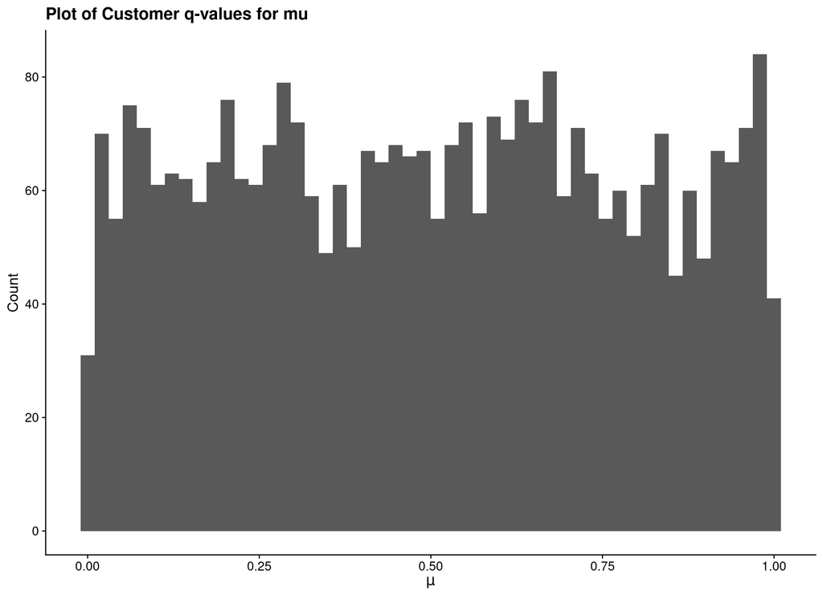

```r
ggplot(customer_postcheck_tbl) +
  geom_histogram(aes(x = post_mu_qval), bins = 50) +
  labs(
    x = expression(mu),
    y = "Count",
    title = "Plot of Customer q-values for mu"
    )
```

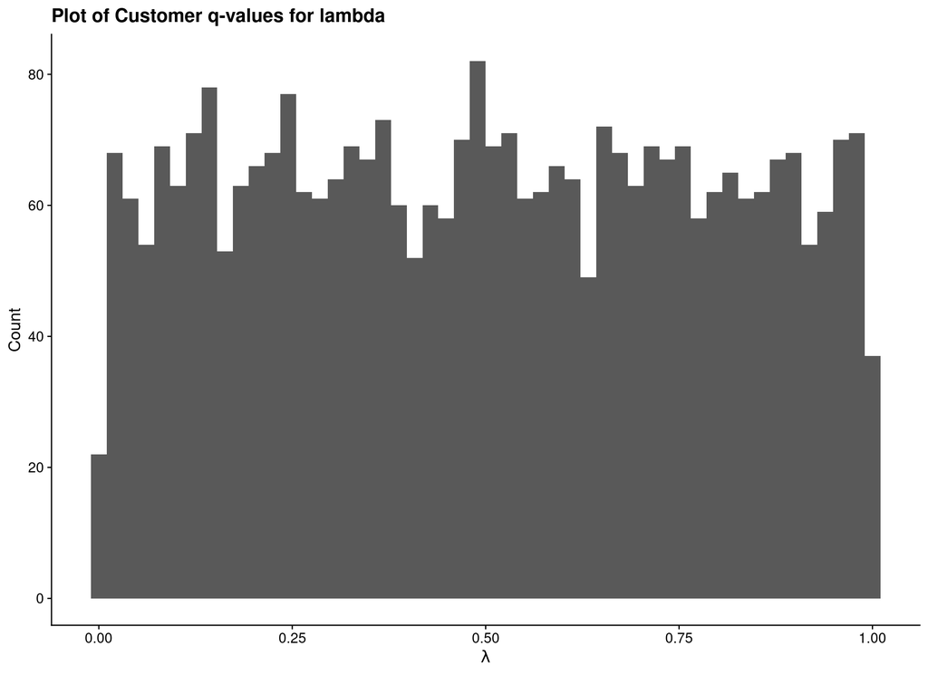

```r
ggplot(customer_postcheck_tbl) +
  geom_histogram(aes(x = post_lambda_qval), bins = 50) +
  labs(
    x = expression(lambda),
    y = "Count",
    title = "Plot of Customer q-values for lambda"
    )
```

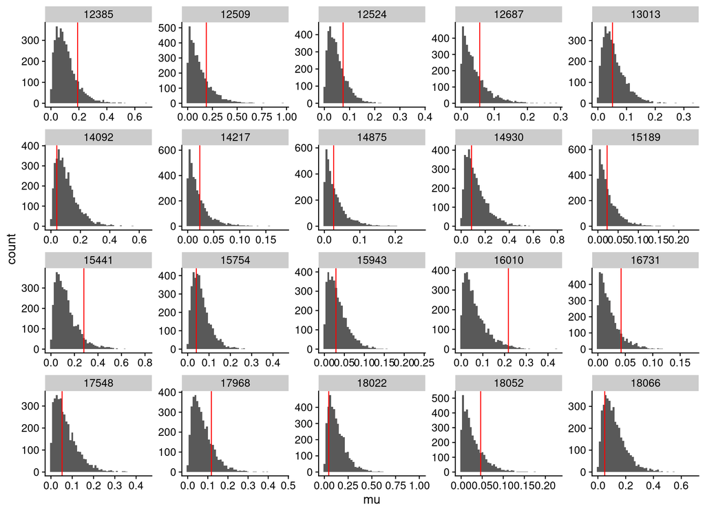

```r
postcheck_facet_plotdata_tbl <- customer_basic_pnbd_fixed_posterior_tbl %>%
  ungroup() %>%
  group_nest(customer_id) %>%
  slice_sample(n = 20) %>%
  unnest(data) %>%
  inner_join(customer_basic_simparams_tbl, by = "customer_id")

ggplot(postcheck_facet_plotdata_tbl) +
  geom_histogram(aes(x = mu), bins = 50) +
  geom_vline(aes(xintercept = customer_mu), colour = "red") +
  facet_wrap(facets = "customer_id", scales = "free")
```

### 2.1.1 Write Model to Disk

```r
pnbd_basic_fixed_stanmodel %>% write_rds("data/pnbd_basic_fixed_stanmodel.rds")
pnbd_basic_fixed_stanfit   %>% write_rds("data/pnbd_basic_fixed_stanfit.rds")
```

## 2.2 Construct Hyper-parameter Model

We now want to improve the model by adding priors around the hyper-parameters for how the $\mu$ and $\lambda$ parameters are distributed. To do this, we try using Gamma distributed hyper-priors.

```r
pnbd_basic_prior_stanmodel <- cmdstan_model(
  "stan_code/clv_pnbd_prior.stan",
  include_paths = "stan_code/",
  pedantic      =  TRUE,
  dir           = "stan_models/"
  )
```

```r
stan_data_lst <- customer_basic_cbs_tbl %>%
  select(-first_tnx_date, -last_tnx_date) %>%
  compose_data(
    lb_mean_a = -1.6000,   lb_mean_b =  1.0000,
    lb_cov_a  = -2.1000,   lb_cov_b  =  1.0000,

    mu_mean_a = -0.0200,   mu_mean_b =  0.2000,
    mu_cov_a  = -0.0002,   mu_cov_b  =  0.0200
    )

pnbd_basic_prior_stanfit <- pnbd_basic_prior_stanmodel$sample(
  data          =  stan_data_lst,
  chains        =              4,
  iter_warmup   =           1000,
  iter_sampling =           1000,
  seed          =            422
  )
```

```
## Running MCMC with 4 parallel chains...
##
## Chain 1 Iteration:    1 / 2000 [  0%]  (Warmup)
## Chain 2 Iteration:    1 / 2000 [  0%]  (Warmup)
## Chain 3 Iteration:    1 / 2000 [  0%]  (Warmup)
## Chain 4 Iteration:    1 / 2000 [  0%]  (Warmup)
## Chain 3 Iteration:  100 / 2000 [  5%]  (Warmup)
## Chain 2 Iteration:  100 / 2000 [  5%]  (Warmup)
## Chain 1 Iteration:  100 / 2000 [  5%]  (Warmup)
## Chain 4 Iteration:  100 / 2000 [  5%]  (Warmup)
## Chain 3 Iteration:  200 / 2000 [ 10%]  (Warmup)
## Chain 2 Iteration:  200 / 2000 [ 10%]  (Warmup)
## Chain 1 Iteration:  200 / 2000 [ 10%]  (Warmup)
## Chain 4 Iteration:  200 / 2000 [ 10%]  (Warmup)
## Chain 2 Iteration:  300 / 2000 [ 15%]  (Warmup)
## Chain 3 Iteration:  300 / 2000 [ 15%]  (Warmup)
## Chain 1 Iteration:  300 / 2000 [ 15%]  (Warmup)
## Chain 4 Iteration:  300 / 2000 [ 15%]  (Warmup)
## Chain 3 Iteration:  400 / 2000 [ 20%]  (Warmup)
## Chain 2 Iteration:  400 / 2000 [ 20%]  (Warmup)
## Chain 1 Iteration:  400 / 2000 [ 20%]  (Warmup)
## Chain 4 Iteration:  400 / 2000 [ 20%]  (Warmup)
## Chain 3 Iteration:  500 / 2000 [ 25%]  (Warmup)
## Chain 2 Iteration:  500 / 2000 [ 25%]  (Warmup)
## Chain 1 Iteration:  500 / 2000 [ 25%]  (Warmup)
## Chain 4 Iteration:  500 / 2000 [ 25%]  (Warmup)
## Chain 2 Iteration:  600 / 2000 [ 30%]  (Warmup)
## Chain 3 Iteration:  600 / 2000 [ 30%]  (Warmup)
## Chain 1 Iteration:  600 / 2000 [ 30%]  (Warmup)
## Chain 4 Iteration:  600 / 2000 [ 30%]  (Warmup)
## Chain 2 Iteration:  700 / 2000 [ 35%]  (Warmup)
## Chain 3 Iteration:  700 / 2000 [ 35%]  (Warmup)
## Chain 1 Iteration:  700 / 2000 [ 35%]  (Warmup)
## Chain 4 Iteration:  700 / 2000 [ 35%]  (Warmup)
## Chain 3 Iteration:  800 / 2000 [ 40%]  (Warmup)
## Chain 2 Iteration:  800 / 2000 [ 40%]  (Warmup)
## Chain 1 Iteration:  800 / 2000 [ 40%]  (Warmup)
## Chain 4 Iteration:  800 / 2000 [ 40%]  (Warmup)
## Chain 3 Iteration:  900 / 2000 [ 45%]  (Warmup)
## Chain 2 Iteration:  900 / 2000 [ 45%]  (Warmup)
```

[output cut: 43 more lines]

```
## Chain 1 Iteration: 1900 / 2000 [ 95%]  (Sampling)
## Chain 2 Iteration: 1900 / 2000 [ 95%]  (Sampling)
## Chain 4 Iteration: 1900 / 2000 [ 95%]  (Sampling)
## Chain 3 Iteration: 2000 / 2000 [100%]  (Sampling)
## Chain 3 finished in 219.4 seconds.
## Chain 1 Iteration: 2000 / 2000 [100%]  (Sampling)
## Chain 1 finished in 220.9 seconds.
## Chain 2 Iteration: 2000 / 2000 [100%]  (Sampling)
## Chain 2 finished in 220.9 seconds.
## Chain 4 Iteration: 2000 / 2000 [100%]  (Sampling)
## Chain 4 finished in 222.7 seconds.
##
## All 4 chains finished successfully.
## Mean chain execution time: 221.0 seconds.
## Total execution time: 223.7 seconds.
```

```r
pnbd_basic_prior_stanfit$summary(
  c("lb_mean", "mu_mean", "mu_cov", "r", "alpha", "s", "beta")
  )
```

```
## # A tibble: 7 × 10
##   variable    mean  median      sd     mad      q5     q95  rhat ess_bulk
##   <chr>      <dbl>   <dbl>   <dbl>   <dbl>   <dbl>   <dbl> <dbl>    <dbl>
## 1 lb_mean   0.440   0.440  0.00726 0.00712  0.428   0.452   1.00    3042.
## 2 mu_mean   0.0587  0.0587 0.00190 0.00188  0.0556  0.0618  1.00    1219.
## 3 mu_cov    0.942   0.942  0.0163  0.0162   0.916   0.969   1.00     874.
## 4 r         1.80    1.80   0.0583  0.0582   1.70    1.90    1.00    1909.
## 5 alpha     4.09    4.09   0.150   0.151    3.85    4.34    1.00    1976.
## 6 s         1.13    1.13   0.0390  0.0388   1.07    1.19    1.00     874.
## 7 beta     19.2    19.2    1.04    1.05    17.6    21.0     1.00     892.
## # … with 1 more variable: ess_tail <dbl>
```

We first want to check the HMC diagnostics.

```r
pnbd_basic_prior_stanfit$cmdstan_diagnose()
```

```
## Processing csv files: /tmp/Rtmpej5ofO/clv_pnbd_prior-202112141554-1-7fb3fb.csv, /tmp/Rtmpej5ofO/clv_pnbd_prior-202112141554-2-7fb3fb.csv, /tmp/Rtmpej5ofO/clv_pnbd_prior-202112141554-3-7fb3fb.csv, /tmp/Rtmpej5ofO/clv_pnbd_prior-202112141554-4-7fb3fb.csv
##
## Checking sampler transitions treedepth.
## Treedepth satisfactory for all transitions.
##
## Checking sampler transitions for divergences.
## No divergent transitions found.
##
## Checking E-BFMI - sampler transitions HMC potential energy.
## E-BFMI satisfactory.
##
## Effective sample size satisfactory.
##
## Split R-hat values satisfactory all parameters.
##
## Processing complete, no problems detected.
```

```r
pnbd_basic_prior_stanfit$save_output_files(
  dir      = "stan_models",
  basename = "pnbd_basic_prior"
)
```

```r
customer_basic_pnbd_prior_draws <- pnbd_basic_prior_stanfit$draws()

customer_basic_pnbd_prior_posterior_tbl <- customer_basic_pnbd_prior_draws %>%
  recover_types(customer_basic_cbs_tbl) %>%
  spread_draws(mu[customer_id], lambda[customer_id]) %>%
  ungroup()

customer_basic_pnbd_prior_posterior_tbl %>% glimpse()
```

```
## Rows: 12,700,000
## Columns: 6
## $ customer_id <chr> "12346", "12346", "12346", "12346", "12346", "12346", "123…
## $ mu          <dbl> 0.01688400, 0.01873270, 0.05102320, 0.02095290, 0.04956330…
## $ .chain      <int> 1, 1, 1, 1, 1, 1, 1, 1, 1, 1, 1, 1, 1, 1, 1, 1, 1, 1, 1, 1…
## $ .iteration  <int> 1, 2, 3, 4, 5, 6, 7, 8, 9, 10, 11, 12, 13, 14, 15, 16, 17,…
## $ .draw       <int> 1, 2, 3, 4, 5, 6, 7, 8, 9, 10, 11, 12, 13, 14, 15, 16, 17,…
## $ lambda      <dbl> 0.321268, 0.338261, 0.262688, 0.370210, 0.224208, 0.277149…
```

## 2.3 Fit Sample with Altenative Prior Parameters

```r
stan_data_lst <- customer_basic_cbs_tbl %>%
  select(-first_tnx_date, -last_tnx_date) %>%
  compose_data(
    lb_mean_a = -1.6000,   lb_mean_b =  1.0000,
    lb_cov_a  = -2.1000,   lb_cov_b  =  1.0000,

    mu_mean_a = -0.0500,   mu_mean_b =  1.0000,
    mu_cov_a  = -0.1250,   mu_cov_b  =  0.5000
    )

pnbd_basic_prior_altprior_stanfit <- pnbd_basic_prior_stanmodel$sample(
  data          =  stan_data_lst,
  chains        =              4,
  iter_warmup   =           1000,
  iter_sampling =           1000,
  seed          =            422
  )
```

```
## Running MCMC with 4 parallel chains...
##
## Chain 1 Iteration:    1 / 2000 [  0%]  (Warmup)
## Chain 2 Iteration:    1 / 2000 [  0%]  (Warmup)
## Chain 3 Iteration:    1 / 2000 [  0%]  (Warmup)
## Chain 4 Iteration:    1 / 2000 [  0%]  (Warmup)
## Chain 3 Iteration:  100 / 2000 [  5%]  (Warmup)
## Chain 1 Iteration:  100 / 2000 [  5%]  (Warmup)
## Chain 2 Iteration:  100 / 2000 [  5%]  (Warmup)
## Chain 4 Iteration:  100 / 2000 [  5%]  (Warmup)
## Chain 3 Iteration:  200 / 2000 [ 10%]  (Warmup)
## Chain 1 Iteration:  200 / 2000 [ 10%]  (Warmup)
## Chain 2 Iteration:  200 / 2000 [ 10%]  (Warmup)
## Chain 3 Iteration:  300 / 2000 [ 15%]  (Warmup)
## Chain 4 Iteration:  200 / 2000 [ 10%]  (Warmup)
## Chain 1 Iteration:  300 / 2000 [ 15%]  (Warmup)
## Chain 2 Iteration:  300 / 2000 [ 15%]  (Warmup)
## Chain 3 Iteration:  400 / 2000 [ 20%]  (Warmup)
## Chain 1 Iteration:  400 / 2000 [ 20%]  (Warmup)
## Chain 4 Iteration:  300 / 2000 [ 15%]  (Warmup)
## Chain 2 Iteration:  400 / 2000 [ 20%]  (Warmup)
## Chain 1 Iteration:  500 / 2000 [ 25%]  (Warmup)
## Chain 4 Iteration:  400 / 2000 [ 20%]  (Warmup)
## Chain 3 Iteration:  500 / 2000 [ 25%]  (Warmup)
## Chain 2 Iteration:  500 / 2000 [ 25%]  (Warmup)
## Chain 1 Iteration:  600 / 2000 [ 30%]  (Warmup)
## Chain 4 Iteration:  500 / 2000 [ 25%]  (Warmup)
## Chain 3 Iteration:  600 / 2000 [ 30%]  (Warmup)
## Chain 2 Iteration:  600 / 2000 [ 30%]  (Warmup)
## Chain 1 Iteration:  700 / 2000 [ 35%]  (Warmup)
## Chain 3 Iteration:  700 / 2000 [ 35%]  (Warmup)
## Chain 4 Iteration:  600 / 2000 [ 30%]  (Warmup)
## Chain 2 Iteration:  700 / 2000 [ 35%]  (Warmup)
## Chain 3 Iteration:  800 / 2000 [ 40%]  (Warmup)
## Chain 1 Iteration:  800 / 2000 [ 40%]  (Warmup)
## Chain 4 Iteration:  700 / 2000 [ 35%]  (Warmup)
## Chain 2 Iteration:  800 / 2000 [ 40%]  (Warmup)
## Chain 3 Iteration:  900 / 2000 [ 45%]  (Warmup)
## Chain 1 Iteration:  900 / 2000 [ 45%]  (Warmup)
## Chain 4 Iteration:  800 / 2000 [ 40%]  (Warmup)
```

[output cut: 43 more lines]

```
## Chain 1 Iteration: 1900 / 2000 [ 95%]  (Sampling)
## Chain 2 Iteration: 1900 / 2000 [ 95%]  (Sampling)
## Chain 3 Iteration: 2000 / 2000 [100%]  (Sampling)
## Chain 3 finished in 195.2 seconds.
## Chain 4 Iteration: 1900 / 2000 [ 95%]  (Sampling)
## Chain 1 Iteration: 2000 / 2000 [100%]  (Sampling)
## Chain 1 finished in 196.7 seconds.
## Chain 2 Iteration: 2000 / 2000 [100%]  (Sampling)
## Chain 2 finished in 197.2 seconds.
## Chain 4 Iteration: 2000 / 2000 [100%]  (Sampling)
## Chain 4 finished in 200.0 seconds.
##
## All 4 chains finished successfully.
## Mean chain execution time: 197.3 seconds.
## Total execution time: 201.1 seconds.
```

```r
pnbd_basic_prior_stanfit$cmdstan_diagnose()
```

```
## Processing csv files: /home/rstudio/workshop/stan_models/pnbd_basic_prior-202112141558-1-632e32.csv, /home/rstudio/workshop/stan_models/pnbd_basic_prior-202112141558-2-632e32.csv, /home/rstudio/workshop/stan_models/pnbd_basic_prior-202112141558-3-632e32.csv, /home/rstudio/workshop/stan_models/pnb…
##
## Checking sampler transitions treedepth.
## Treedepth satisfactory for all transitions.
##
## Checking sampler transitions for divergences.
## No divergent transitions found.
##
## Checking E-BFMI - sampler transitions HMC potential energy.
## E-BFMI satisfactory.
##
## Effective sample size satisfactory.
##
## Split R-hat values satisfactory all parameters.
##
## Processing complete, no problems detected.
```

```r
pnbd_basic_prior_altprior_stanfit$summary(
  c("lb_mean", "mu_mean", "mu_cov", "r", "alpha", "s", "beta")
  )
```

```
## # A tibble: 7 × 10
##   variable    mean  median      sd     mad      q5     q95  rhat ess_bulk
##   <chr>      <dbl>   <dbl>   <dbl>   <dbl>   <dbl>   <dbl> <dbl>    <dbl>
## 1 lb_mean   0.437   0.437  0.00729 0.00733  0.425   0.449   1.00   3872.
## 2 mu_mean   0.0456  0.0455 0.00181 0.00184  0.0427  0.0487  1.03    106.
## 3 mu_cov    0.642   0.641  0.0458  0.0458   0.568   0.719   1.07     51.1
## 4 r         1.79    1.79   0.0585  0.0608   1.70    1.89    1.00   2201.
## 5 alpha     4.11    4.11   0.156   0.158    3.86    4.37    1.00   2353.
## 6 s         2.46    2.43   0.360   0.343    1.93    3.10    1.07     51.1
## 7 beta     54.4    53.6    9.68    9.28    40.1    71.7     1.07     54.4
## # … with 1 more variable: ess_tail <dbl>
```

```r
stan_data_lst <- customer_basic_cbs_tbl %>%
  filter(first_tnx_date < as.Date("2010-04-01")) %>%
  select(-first_tnx_date, -last_tnx_date) %>%
  compose_data(
    lb_mean_a = -1.6000,   lb_mean_b =  1.0000,
    lb_cov_a  = -2.1000,   lb_cov_b  =  1.0000,

    mu_mean_a = -0.0500,   mu_mean_b =  1.0000,
    mu_cov_a  = -0.1250,   mu_cov_b  =  0.5000
    )

pnbd_basic_prior_altprior_earlycohort_stanfit <- pnbd_basic_prior_stanmodel$sample(
  data          =  stan_data_lst,
  chains        =              4,
  iter_warmup   =           1000,
  iter_sampling =           1000,
  seed          =            422
  )
```

```
## Running MCMC with 4 parallel chains...
##
## Chain 1 Iteration:    1 / 2000 [  0%]  (Warmup)
## Chain 2 Iteration:    1 / 2000 [  0%]  (Warmup)
## Chain 3 Iteration:    1 / 2000 [  0%]  (Warmup)
## Chain 4 Iteration:    1 / 2000 [  0%]  (Warmup)
## Chain 3 Iteration:  100 / 2000 [  5%]  (Warmup)
## Chain 1 Iteration:  100 / 2000 [  5%]  (Warmup)
## Chain 4 Iteration:  100 / 2000 [  5%]  (Warmup)
## Chain 2 Iteration:  100 / 2000 [  5%]  (Warmup)
## Chain 3 Iteration:  200 / 2000 [ 10%]  (Warmup)
## Chain 1 Iteration:  200 / 2000 [ 10%]  (Warmup)
## Chain 4 Iteration:  200 / 2000 [ 10%]  (Warmup)
## Chain 2 Iteration:  200 / 2000 [ 10%]  (Warmup)
## Chain 3 Iteration:  300 / 2000 [ 15%]  (Warmup)
## Chain 1 Iteration:  300 / 2000 [ 15%]  (Warmup)
## Chain 4 Iteration:  300 / 2000 [ 15%]  (Warmup)
## Chain 2 Iteration:  300 / 2000 [ 15%]  (Warmup)
## Chain 3 Iteration:  400 / 2000 [ 20%]  (Warmup)
## Chain 1 Iteration:  400 / 2000 [ 20%]  (Warmup)
## Chain 4 Iteration:  400 / 2000 [ 20%]  (Warmup)
## Chain 2 Iteration:  400 / 2000 [ 20%]  (Warmup)
## Chain 3 Iteration:  500 / 2000 [ 25%]  (Warmup)
## Chain 1 Iteration:  500 / 2000 [ 25%]  (Warmup)
## Chain 4 Iteration:  500 / 2000 [ 25%]  (Warmup)
## Chain 2 Iteration:  500 / 2000 [ 25%]  (Warmup)
## Chain 3 Iteration:  600 / 2000 [ 30%]  (Warmup)
## Chain 4 Iteration:  600 / 2000 [ 30%]  (Warmup)
## Chain 1 Iteration:  600 / 2000 [ 30%]  (Warmup)
## Chain 2 Iteration:  600 / 2000 [ 30%]  (Warmup)
## Chain 3 Iteration:  700 / 2000 [ 35%]  (Warmup)
## Chain 4 Iteration:  700 / 2000 [ 35%]  (Warmup)
## Chain 1 Iteration:  700 / 2000 [ 35%]  (Warmup)
## Chain 2 Iteration:  700 / 2000 [ 35%]  (Warmup)
## Chain 3 Iteration:  800 / 2000 [ 40%]  (Warmup)
## Chain 1 Iteration:  800 / 2000 [ 40%]  (Warmup)
## Chain 4 Iteration:  800 / 2000 [ 40%]  (Warmup)
## Chain 2 Iteration:  800 / 2000 [ 40%]  (Warmup)
## Chain 3 Iteration:  900 / 2000 [ 45%]  (Warmup)
## Chain 1 Iteration:  900 / 2000 [ 45%]  (Warmup)
```

[output cut: 43 more lines]

```
## Chain 4 Iteration: 1900 / 2000 [ 95%]  (Sampling)
## Chain 1 Iteration: 1900 / 2000 [ 95%]  (Sampling)
## Chain 2 Iteration: 1900 / 2000 [ 95%]  (Sampling)
## Chain 3 Iteration: 2000 / 2000 [100%]  (Sampling)
## Chain 3 finished in 79.5 seconds.
## Chain 4 Iteration: 2000 / 2000 [100%]  (Sampling)
## Chain 4 finished in 79.9 seconds.
## Chain 1 Iteration: 2000 / 2000 [100%]  (Sampling)
## Chain 1 finished in 80.9 seconds.
## Chain 2 Iteration: 2000 / 2000 [100%]  (Sampling)
## Chain 2 finished in 81.1 seconds.
##
## All 4 chains finished successfully.
## Mean chain execution time: 80.4 seconds.
## Total execution time: 81.6 seconds.
```

```r
pnbd_basic_prior_altprior_earlycohort_stanfit$cmdstan_diagnose()
```

```
## Processing csv files: /tmp/Rtmpej5ofO/clv_pnbd_prior-202112141603-1-49d59d.csv, /tmp/Rtmpej5ofO/clv_pnbd_prior-202112141603-2-49d59d.csv, /tmp/Rtmpej5ofO/clv_pnbd_prior-202112141603-3-49d59d.csv, /tmp/Rtmpej5ofO/clv_pnbd_prior-202112141603-4-49d59d.csv
##
## Checking sampler transitions treedepth.
## Treedepth satisfactory for all transitions.
##
## Checking sampler transitions for divergences.
## No divergent transitions found.
##
## Checking E-BFMI - sampler transitions HMC potential energy.
## The E-BFMI, 0.250296, is below the nominal threshold of 0.3 which suggests that HMC may have trouble exploring the target distribution.
## If possible, try to reparameterize the model.
##
## Effective sample size satisfactory.
##
## Split R-hat values satisfactory all parameters.
##
## Processing complete.
```

```r
pnbd_basic_prior_altprior_earlycohort_stanfit$summary(
  c("lb_mean", "mu_mean", "mu_cov", "r", "alpha", "s", "beta")
  )
```

```
## # A tibble: 7 × 10
##   variable    mean  median      sd     mad      q5     q95  rhat ess_bulk
##   <chr>      <dbl>   <dbl>   <dbl>   <dbl>   <dbl>   <dbl> <dbl>    <dbl>
## 1 lb_mean   0.423   0.422  0.0101  0.00998  0.406   0.440   1.00    5891.
## 2 mu_mean   0.0450  0.0449 0.00237 0.00235  0.0412  0.0490  1.01     315.
## 3 mu_cov    0.713   0.714  0.0515  0.0504   0.627   0.798   1.02     160.
## 4 r         1.72    1.72   0.0774  0.0771   1.60    1.86    1.00    3094.
## 5 alpha     4.08    4.07   0.214   0.220    3.74    4.44    1.00    3488.
## 6 s         2.00    1.96   0.296   0.278    1.57    2.54    1.02     160.
## 7 beta     44.7    43.8    8.50    7.84    32.6    60.2     1.02     163.
## # … with 1 more variable: ess_tail <dbl>
```

### 2.3.1 Write Model to Disk

```r
pnbd_basic_prior_stanmodel %>% write_rds("data/pnbd_basic_prior_stanmodel.rds")
pnbd_basic_prior_stanfit   %>% write_rds("data/pnbd_basic_prior_stanfit.rds")
```

## 2.4 Construct Fixed-Coefficient of Variance Model

In this model we fix the coefficient of variation for the hyperparameters and model the means - we then sample fixing different values for the coefficient of variance.

```r
pnbd_basic_fixedcov_stanmodel <- cmdstan_model(
  "stan_code/clv_pnbd_fixedcov.stan",
  include_paths = "stan_code/",
  pedantic      =  TRUE,
  dir           = "stan_models/"
  )
```

### 2.4.1 CoV = 1.0

```r
stan_data_lst <- customer_basic_cbs_tbl %>%
  select(-first_tnx_date, -last_tnx_date) %>%
  compose_data(
    mu_cov = 1.0,
    lb_cov = 1.0
    )

pnbd_basic_fixedcov10_stanfit <- pnbd_basic_fixedcov_stanmodel$sample(
  data          =  stan_data_lst,
  chains        =              4,
  iter_warmup   =           1000,
  iter_sampling =           1000,
  seed          =            423
  )
```

```
## Running MCMC with 4 parallel chains...
##
## Chain 1 Iteration:    1 / 2000 [  0%]  (Warmup)
## Chain 2 Iteration:    1 / 2000 [  0%]  (Warmup)
## Chain 3 Iteration:    1 / 2000 [  0%]  (Warmup)
## Chain 4 Iteration:    1 / 2000 [  0%]  (Warmup)
## Chain 2 Iteration:  100 / 2000 [  5%]  (Warmup)
## Chain 4 Iteration:  100 / 2000 [  5%]  (Warmup)
## Chain 3 Iteration:  100 / 2000 [  5%]  (Warmup)
## Chain 1 Iteration:  100 / 2000 [  5%]  (Warmup)
## Chain 2 Iteration:  200 / 2000 [ 10%]  (Warmup)
## Chain 4 Iteration:  200 / 2000 [ 10%]  (Warmup)
## Chain 3 Iteration:  200 / 2000 [ 10%]  (Warmup)
## Chain 1 Iteration:  200 / 2000 [ 10%]  (Warmup)
## Chain 4 Iteration:  300 / 2000 [ 15%]  (Warmup)
## Chain 2 Iteration:  300 / 2000 [ 15%]  (Warmup)
## Chain 3 Iteration:  300 / 2000 [ 15%]  (Warmup)
## Chain 1 Iteration:  300 / 2000 [ 15%]  (Warmup)
## Chain 4 Iteration:  400 / 2000 [ 20%]  (Warmup)
## Chain 2 Iteration:  400 / 2000 [ 20%]  (Warmup)
## Chain 3 Iteration:  400 / 2000 [ 20%]  (Warmup)
## Chain 1 Iteration:  400 / 2000 [ 20%]  (Warmup)
## Chain 4 Iteration:  500 / 2000 [ 25%]  (Warmup)
## Chain 2 Iteration:  500 / 2000 [ 25%]  (Warmup)
## Chain 3 Iteration:  500 / 2000 [ 25%]  (Warmup)
## Chain 1 Iteration:  500 / 2000 [ 25%]  (Warmup)
## Chain 4 Iteration:  600 / 2000 [ 30%]  (Warmup)
## Chain 2 Iteration:  600 / 2000 [ 30%]  (Warmup)
## Chain 3 Iteration:  600 / 2000 [ 30%]  (Warmup)
## Chain 1 Iteration:  600 / 2000 [ 30%]  (Warmup)
## Chain 4 Iteration:  700 / 2000 [ 35%]  (Warmup)
## Chain 2 Iteration:  700 / 2000 [ 35%]  (Warmup)
## Chain 3 Iteration:  700 / 2000 [ 35%]  (Warmup)
## Chain 1 Iteration:  700 / 2000 [ 35%]  (Warmup)
## Chain 4 Iteration:  800 / 2000 [ 40%]  (Warmup)
## Chain 2 Iteration:  800 / 2000 [ 40%]  (Warmup)
## Chain 3 Iteration:  800 / 2000 [ 40%]  (Warmup)
## Chain 1 Iteration:  800 / 2000 [ 40%]  (Warmup)
## Chain 4 Iteration:  900 / 2000 [ 45%]  (Warmup)
## Chain 2 Iteration:  900 / 2000 [ 45%]  (Warmup)
```

[output cut: 43 more lines]

```
## Chain 2 Iteration: 1900 / 2000 [ 95%]  (Sampling)
## Chain 3 Iteration: 1900 / 2000 [ 95%]  (Sampling)
## Chain 1 Iteration: 1900 / 2000 [ 95%]  (Sampling)
## Chain 4 Iteration: 2000 / 2000 [100%]  (Sampling)
## Chain 4 finished in 191.2 seconds.
## Chain 2 Iteration: 2000 / 2000 [100%]  (Sampling)
## Chain 2 finished in 193.2 seconds.
## Chain 3 Iteration: 2000 / 2000 [100%]  (Sampling)
## Chain 3 finished in 194.1 seconds.
## Chain 1 Iteration: 2000 / 2000 [100%]  (Sampling)
## Chain 1 finished in 195.1 seconds.
##
## All 4 chains finished successfully.
## Mean chain execution time: 193.4 seconds.
## Total execution time: 195.4 seconds.
```

```r
pnbd_basic_fixedcov10_stanfit$summary(
  c("lb_mean", "mu_mean", "r", "alpha", "s", "beta")
  )
```

```
## # A tibble: 6 × 10
##   variable    mean  median      sd     mad      q5     q95  rhat ess_bulk
##   <chr>      <dbl>   <dbl>   <dbl>   <dbl>   <dbl>   <dbl> <dbl>    <dbl>
## 1 lb_mean   0.447   0.447  0.00939 0.00949  0.432   0.462   1.00    4558.
## 2 mu_mean   0.0545  0.0545 0.00180 0.00180  0.0517  0.0576  1.00    1898.
## 3 r         1       1      0       0        1       1      NA         NA
## 4 alpha     2.24    2.24   0.0470  0.0474   2.16    2.32    1.00    4558.
## 5 s         1       1      0       0        1       1      NA         NA
## 6 beta     18.4    18.3    0.605   0.606   17.4    19.3     1.00    1898.
## # … with 1 more variable: ess_tail <dbl>
```

We first want to check the HMC diagnostics.

```r
pnbd_basic_fixedcov10_stanfit$cmdstan_diagnose()
```

```
## Processing csv files: /tmp/Rtmpej5ofO/clv_pnbd_fixedcov-202112141604-1-934db7.csv, /tmp/Rtmpej5ofO/clv_pnbd_fixedcov-202112141604-2-934db7.csv, /tmp/Rtmpej5ofO/clv_pnbd_fixedcov-202112141604-3-934db7.csv, /tmp/Rtmpej5ofO/clv_pnbd_fixedcov-202112141604-4-934db7.csv
##
## Checking sampler transitions treedepth.
## Treedepth satisfactory for all transitions.
##
## Checking sampler transitions for divergences.
## No divergent transitions found.
##
## Checking E-BFMI - sampler transitions HMC potential energy.
## E-BFMI satisfactory.
##
## Effective sample size satisfactory.
##
## Split R-hat values satisfactory all parameters.
##
## Processing complete, no problems detected.
```

### 2.4.2 CoV = 2.0

We now refit the model with a higher level of coefficient-of-variance.

```r
stan_data_lst <- customer_basic_cbs_tbl %>%
  select(-first_tnx_date, -last_tnx_date) %>%
  compose_data(
    mu_cov = 2.0,
    lb_cov = 2.0
    )

pnbd_basic_fixedcov20_stanfit <- pnbd_basic_fixedcov_stanmodel$sample(
  data          =  stan_data_lst,
  chains        =              4,
  iter_warmup   =           1000,
  iter_sampling =           1000,
  seed          =            424
  )
```

```
## Running MCMC with 4 parallel chains...
##
## Chain 1 Iteration:    1 / 2000 [  0%]  (Warmup)
## Chain 2 Iteration:    1 / 2000 [  0%]  (Warmup)
## Chain 3 Iteration:    1 / 2000 [  0%]  (Warmup)
## Chain 4 Iteration:    1 / 2000 [  0%]  (Warmup)
## Chain 4 Iteration:  100 / 2000 [  5%]  (Warmup)
## Chain 1 Iteration:  100 / 2000 [  5%]  (Warmup)
## Chain 2 Iteration:  100 / 2000 [  5%]  (Warmup)
## Chain 3 Iteration:  100 / 2000 [  5%]  (Warmup)
## Chain 4 Iteration:  200 / 2000 [ 10%]  (Warmup)
## Chain 1 Iteration:  200 / 2000 [ 10%]  (Warmup)
## Chain 2 Iteration:  200 / 2000 [ 10%]  (Warmup)
## Chain 3 Iteration:  200 / 2000 [ 10%]  (Warmup)
## Chain 4 Iteration:  300 / 2000 [ 15%]  (Warmup)
## Chain 1 Iteration:  300 / 2000 [ 15%]  (Warmup)
## Chain 2 Iteration:  300 / 2000 [ 15%]  (Warmup)
## Chain 3 Iteration:  300 / 2000 [ 15%]  (Warmup)
## Chain 4 Iteration:  400 / 2000 [ 20%]  (Warmup)
## Chain 1 Iteration:  400 / 2000 [ 20%]  (Warmup)
## Chain 2 Iteration:  400 / 2000 [ 20%]  (Warmup)
## Chain 3 Iteration:  400 / 2000 [ 20%]  (Warmup)
## Chain 4 Iteration:  500 / 2000 [ 25%]  (Warmup)
## Chain 1 Iteration:  500 / 2000 [ 25%]  (Warmup)
## Chain 2 Iteration:  500 / 2000 [ 25%]  (Warmup)
## Chain 4 Iteration:  600 / 2000 [ 30%]  (Warmup)
## Chain 3 Iteration:  500 / 2000 [ 25%]  (Warmup)
## Chain 1 Iteration:  600 / 2000 [ 30%]  (Warmup)
## Chain 2 Iteration:  600 / 2000 [ 30%]  (Warmup)
## Chain 4 Iteration:  700 / 2000 [ 35%]  (Warmup)
## Chain 3 Iteration:  600 / 2000 [ 30%]  (Warmup)
## Chain 1 Iteration:  700 / 2000 [ 35%]  (Warmup)
## Chain 2 Iteration:  700 / 2000 [ 35%]  (Warmup)
## Chain 4 Iteration:  800 / 2000 [ 40%]  (Warmup)
## Chain 3 Iteration:  700 / 2000 [ 35%]  (Warmup)
## Chain 1 Iteration:  800 / 2000 [ 40%]  (Warmup)
## Chain 2 Iteration:  800 / 2000 [ 40%]  (Warmup)
## Chain 4 Iteration:  900 / 2000 [ 45%]  (Warmup)
## Chain 1 Iteration:  900 / 2000 [ 45%]  (Warmup)
## Chain 3 Iteration:  800 / 2000 [ 40%]  (Warmup)
```

[output cut: 43 more lines]

```
## Chain 2 Iteration: 1900 / 2000 [ 95%]  (Sampling)
## Chain 3 Iteration: 1800 / 2000 [ 90%]  (Sampling)
## Chain 4 Iteration: 2000 / 2000 [100%]  (Sampling)
## Chain 4 finished in 386.2 seconds.
## Chain 3 Iteration: 1900 / 2000 [ 95%]  (Sampling)
## Chain 1 Iteration: 2000 / 2000 [100%]  (Sampling)
## Chain 2 Iteration: 2000 / 2000 [100%]  (Sampling)
## Chain 1 finished in 394.0 seconds.
## Chain 2 finished in 393.9 seconds.
## Chain 3 Iteration: 2000 / 2000 [100%]  (Sampling)
## Chain 3 finished in 400.9 seconds.
##
## All 4 chains finished successfully.
## Mean chain execution time: 393.8 seconds.
## Total execution time: 401.5 seconds.
```

```r
pnbd_basic_fixedcov20_stanfit$summary(
  c("lb_mean", "mu_mean", "r", "alpha", "s", "beta")
  )
```

```
## # A tibble: 6 × 10
##   variable   mean median      sd     mad     q5    q95  rhat ess_bulk ess_tail
##   <chr>     <dbl>  <dbl>   <dbl>   <dbl>  <dbl>  <dbl> <dbl>    <dbl>    <dbl>
## 1 lb_mean  0.473  0.473  0.0179  0.0177  0.445  0.504   1.00    4455.    3296.
## 2 mu_mean  0.0761 0.0760 0.00381 0.00380 0.0701 0.0825  1.00    3114.    3007.
## 3 r        0.25   0.25   0       0       0.25   0.25   NA         NA       NA
## 4 alpha    0.529  0.529  0.0200  0.0198  0.496  0.562   1.00    4455.    3296.
## 5 s        0.25   0.25   0       0       0.25   0.25   NA         NA       NA
## 6 beta     3.29   3.29   0.164   0.164   3.03   3.57    1.00    3114.    3007.
```

We first want to check the HMC diagnostics.

```r
pnbd_basic_fixedcov20_stanfit$cmdstan_diagnose()
```

```
## Processing csv files: /tmp/Rtmpej5ofO/clv_pnbd_fixedcov-202112141608-1-913d1e.csv, /tmp/Rtmpej5ofO/clv_pnbd_fixedcov-202112141608-2-913d1e.csv, /tmp/Rtmpej5ofO/clv_pnbd_fixedcov-202112141608-3-913d1e.csv, /tmp/Rtmpej5ofO/clv_pnbd_fixedcov-202112141608-4-913d1e.csv
##
## Checking sampler transitions treedepth.
## Treedepth satisfactory for all transitions.
##
## Checking sampler transitions for divergences.
## No divergent transitions found.
##
## Checking E-BFMI - sampler transitions HMC potential energy.
## E-BFMI satisfactory.
##
## Effective sample size satisfactory.
##
## Split R-hat values satisfactory all parameters.
##
## Processing complete, no problems detected.
```

### 2.4.3 CoV = 0.5

```r
stan_data_lst <- customer_basic_cbs_tbl %>%
  select(-first_tnx_date, -last_tnx_date) %>%
  compose_data(
    mu_cov = 0.5,
    lb_cov = 0.5
    )

pnbd_basic_fixedcov05_stanfit <- pnbd_basic_fixedcov_stanmodel$sample(
  data          =  stan_data_lst,
  chains        =              4,
  iter_warmup   =           1000,
  iter_sampling =           1000,
  seed          =            425
  )
```

```
## Running MCMC with 4 parallel chains...
##
## Chain 1 Iteration:    1 / 2000 [  0%]  (Warmup)
## Chain 2 Iteration:    1 / 2000 [  0%]  (Warmup)
## Chain 3 Iteration:    1 / 2000 [  0%]  (Warmup)
## Chain 4 Iteration:    1 / 2000 [  0%]  (Warmup)
## Chain 2 Iteration:  100 / 2000 [  5%]  (Warmup)
## Chain 1 Iteration:  100 / 2000 [  5%]  (Warmup)
## Chain 3 Iteration:  100 / 2000 [  5%]  (Warmup)
## Chain 4 Iteration:  100 / 2000 [  5%]  (Warmup)
## Chain 2 Iteration:  200 / 2000 [ 10%]  (Warmup)
## Chain 1 Iteration:  200 / 2000 [ 10%]  (Warmup)
## Chain 3 Iteration:  200 / 2000 [ 10%]  (Warmup)
## Chain 4 Iteration:  200 / 2000 [ 10%]  (Warmup)
## Chain 2 Iteration:  300 / 2000 [ 15%]  (Warmup)
## Chain 1 Iteration:  300 / 2000 [ 15%]  (Warmup)
## Chain 3 Iteration:  300 / 2000 [ 15%]  (Warmup)
## Chain 2 Iteration:  400 / 2000 [ 20%]  (Warmup)
## Chain 4 Iteration:  300 / 2000 [ 15%]  (Warmup)
## Chain 1 Iteration:  400 / 2000 [ 20%]  (Warmup)
## Chain 3 Iteration:  400 / 2000 [ 20%]  (Warmup)
## Chain 2 Iteration:  500 / 2000 [ 25%]  (Warmup)
## Chain 4 Iteration:  400 / 2000 [ 20%]  (Warmup)
## Chain 1 Iteration:  500 / 2000 [ 25%]  (Warmup)
## Chain 3 Iteration:  500 / 2000 [ 25%]  (Warmup)
## Chain 2 Iteration:  600 / 2000 [ 30%]  (Warmup)
## Chain 4 Iteration:  500 / 2000 [ 25%]  (Warmup)
## Chain 1 Iteration:  600 / 2000 [ 30%]  (Warmup)
## Chain 3 Iteration:  600 / 2000 [ 30%]  (Warmup)
## Chain 2 Iteration:  700 / 2000 [ 35%]  (Warmup)
## Chain 4 Iteration:  600 / 2000 [ 30%]  (Warmup)
## Chain 1 Iteration:  700 / 2000 [ 35%]  (Warmup)
## Chain 3 Iteration:  700 / 2000 [ 35%]  (Warmup)
## Chain 2 Iteration:  800 / 2000 [ 40%]  (Warmup)
## Chain 4 Iteration:  700 / 2000 [ 35%]  (Warmup)
## Chain 1 Iteration:  800 / 2000 [ 40%]  (Warmup)
## Chain 3 Iteration:  800 / 2000 [ 40%]  (Warmup)
## Chain 2 Iteration:  900 / 2000 [ 45%]  (Warmup)
## Chain 4 Iteration:  800 / 2000 [ 40%]  (Warmup)
## Chain 1 Iteration:  900 / 2000 [ 45%]  (Warmup)
```

[output cut: 43 more lines]

```
## Chain 1 Iteration: 1900 / 2000 [ 95%]  (Sampling)
## Chain 3 Iteration: 1900 / 2000 [ 95%]  (Sampling)
## Chain 2 Iteration: 2000 / 2000 [100%]  (Sampling)
## Chain 4 Iteration: 1900 / 2000 [ 95%]  (Sampling)
## Chain 2 finished in 180.8 seconds.
## Chain 1 Iteration: 2000 / 2000 [100%]  (Sampling)
## Chain 1 finished in 183.2 seconds.
## Chain 3 Iteration: 2000 / 2000 [100%]  (Sampling)
## Chain 3 finished in 183.3 seconds.
## Chain 4 Iteration: 2000 / 2000 [100%]  (Sampling)
## Chain 4 finished in 185.5 seconds.
##
## All 4 chains finished successfully.
## Mean chain execution time: 183.2 seconds.
## Total execution time: 186.5 seconds.
```

```r
pnbd_basic_fixedcov05_stanfit$summary(
  c("lb_mean", "mu_mean", "r", "alpha", "s", "beta")
  )
```

```
## # A tibble: 6 × 10
##   variable    mean  median      sd     mad      q5     q95  rhat ess_bulk
##   <chr>      <dbl>   <dbl>   <dbl>   <dbl>   <dbl>   <dbl> <dbl>    <dbl>
## 1 lb_mean   0.428   0.428  0.00544 0.00533  0.419   0.436   1.00    3552.
## 2 mu_mean   0.0437  0.0437 0.00105 0.00104  0.0420  0.0454  1.00    1074.
## 3 r         4       4      0       0        4       4      NA         NA
## 4 alpha     9.36    9.35   0.119   0.116    9.17    9.55    1.00    3552.
## 5 s         4       4      0       0        4       4      NA         NA
## 6 beta     91.6    91.5    2.21    2.18    88.0    95.2     1.00    1074.
## # … with 1 more variable: ess_tail <dbl>
```

We first want to check the HMC diagnostics.

```r
pnbd_basic_fixedcov05_stanfit$cmdstan_diagnose()
```

```
## Processing csv files: /tmp/Rtmpej5ofO/clv_pnbd_fixedcov-202112141616-1-1f22da.csv, /tmp/Rtmpej5ofO/clv_pnbd_fixedcov-202112141616-2-1f22da.csv, /tmp/Rtmpej5ofO/clv_pnbd_fixedcov-202112141616-3-1f22da.csv, /tmp/Rtmpej5ofO/clv_pnbd_fixedcov-202112141616-4-1f22da.csv
##
## Checking sampler transitions treedepth.
## Treedepth satisfactory for all transitions.
##
## Checking sampler transitions for divergences.
## No divergent transitions found.
##
## Checking E-BFMI - sampler transitions HMC potential energy.
## E-BFMI satisfactory.
##
## Effective sample size satisfactory.
##
## Split R-hat values satisfactory all parameters.
##
## Processing complete, no problems detected.
```

### 2.4.4 Compare CoV Samples

We now combine all the posterior data and compare the parameter estimates for each of the different parameter values.

```r
post05_customer_tbl <- pnbd_basic_fixedcov05_stanfit$draws() %>%
  recover_types(customer_basic_cbs_tbl) %>%
  spread_draws(mu[customer_id], lambda[customer_id]) %>%
  ungroup()


post10_customer_tbl <- pnbd_basic_fixedcov10_stanfit$draws() %>%
  recover_types(customer_basic_cbs_tbl) %>%
  spread_draws(mu[customer_id], lambda[customer_id]) %>%
  ungroup()


post20_customer_tbl <- pnbd_basic_fixedcov20_stanfit$draws() %>%
  recover_types(customer_basic_cbs_tbl) %>%
  spread_draws(mu[customer_id], lambda[customer_id]) %>%
  ungroup()


post_custdata_tbl <- list(
    `CoV 0.5` = post05_customer_tbl,
    `CoV 1.0` = post10_customer_tbl,
    `CoV 2.0` = post20_customer_tbl
    ) %>%
  bind_rows(.id = "label")

post_custdata_tbl %>% glimpse()
```

```
## Rows: 38,100,000
## Columns: 7
## $ label       <chr> "CoV 0.5", "CoV 0.5", "CoV 0.5", "CoV 0.5", "CoV 0.5", "Co…
## $ customer_id <chr> "12346", "12346", "12346", "12346", "12346", "12346", "123…
## $ mu          <dbl> 0.0332269, 0.0265882, 0.0441458, 0.0373203, 0.0352152, 0.0…
## $ .chain      <int> 1, 1, 1, 1, 1, 1, 1, 1, 1, 1, 1, 1, 1, 1, 1, 1, 1, 1, 1, 1…
## $ .iteration  <int> 1, 2, 3, 4, 5, 6, 7, 8, 9, 10, 11, 12, 13, 14, 15, 16, 17,…
## $ .draw       <int> 1, 2, 3, 4, 5, 6, 7, 8, 9, 10, 11, 12, 13, 14, 15, 16, 17,…
## $ lambda      <dbl> 0.305204, 0.303747, 0.329774, 0.284904, 0.342798, 0.300335…
```

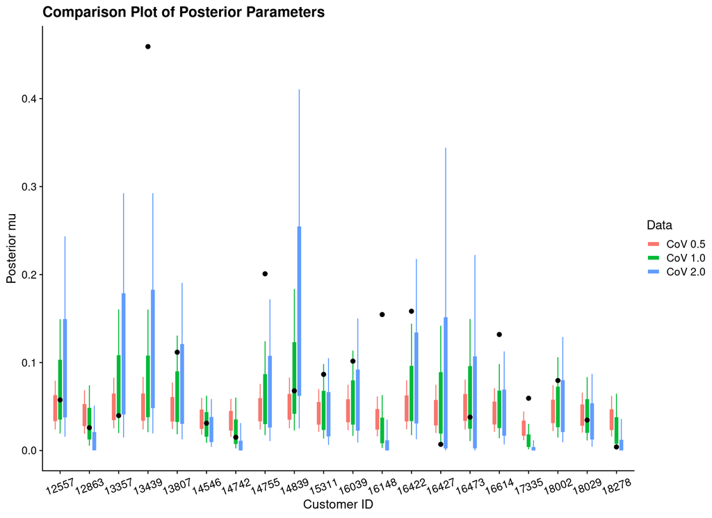

```r
qn_prob  <- c(0.05, 0.10, 0.25, 0.50, 0.75, 0.90, 0.95)
qn_label <- sprintf("p%02d", qn_prob * 100)

summdata_tbl <- post_custdata_tbl %>%
  group_by(label, customer_id) %>%
  summarise(
    .groups = "drop",

    qn     = glue("{qn_label}"),
    mu     = quantile(mu,     probs = qn_prob),
    lambda = quantile(lambda, probs = qn_prob)
    )

plot_tbl <- summdata_tbl %>%
  group_nest(customer_id, .key = "cust_data") %>%
  slice_sample(n = 20) %>%
  unnest(cust_data) %>%
  pivot_wider(
    id_cols = c(label, customer_id),
    names_from = "qn",
    values_from = c(mu, lambda)
    )

cust_data_tbl <- customer_basic_simparams_tbl %>%
  semi_join(plot_tbl, by = "customer_id")


ggplot() +
  geom_errorbar(
    aes(x = customer_id, ymin = mu_p25, ymax = mu_p75, colour = label),
    data = plot_tbl, width = 0, size = 2.0, position = position_dodge(width = 0.5)) +
  geom_errorbar(
    aes(x = customer_id, ymin = mu_p10, ymax = mu_p90, colour = label),
    data = plot_tbl, width = 0, size = 0.5, position = position_dodge(width = 0.5)) +
  geom_point(
    aes(x = customer_id, y = customer_mu),
    data = cust_data_tbl, size = 2) +
  labs(
    x      = "Customer ID",
    y      = "Posterior mu",
    colour = "Data"
    ) +
  ggtitle("Comparison Plot of Posterior Parameters") +
  theme(axis.text.x = element_text(angle = 20, vjust = 0.5))
```

```r
# pnbd_basic_fixedcov_stanmodel %>% write_rds("data/pnbd_basic_fixedcov_stanmodel.rds")
# pnbd_basic_fixedcov05_stanfit %>% write_rds("data/pnbd_basic_fixedcov05_stanfit.rds")
# pnbd_basic_fixedcov10_stanfit %>% write_rds("data/pnbd_basic_fixedcov10_stanfit.rds")
# pnbd_basic_fixedcov20_stanfit %>% write_rds("data/pnbd_basic_fixedcov20_stanfit.rds")
```

## 2.5 Construct Fixed Single CoV Parameter Model

```r
pnbd_basic_fixedlbcov_stanmodel <- cmdstan_model(
  "stan_code/clv_pnbd_fixedlbcov.stan",
  include_paths = "stan_code/",
  pedantic      =  TRUE,
  dir           = "stan_models/"
  )
```

```r
stan_data_lst <- customer_basic_cbs_tbl %>%
  select(-first_tnx_date, -last_tnx_date) %>%
  compose_data(
    lb_cov = 1
    )

pnbd_basic_fixedlbcov_stanfit <- pnbd_basic_fixedlbcov_stanmodel$sample(
  data          =  stan_data_lst,
  chains        =              4,
  iter_warmup   =           1000,
  iter_sampling =           1000,
  seed          =            426
  )
```

```
## Running MCMC with 4 parallel chains...
##
## Chain 1 Iteration:    1 / 2000 [  0%]  (Warmup)
## Chain 2 Iteration:    1 / 2000 [  0%]  (Warmup)
## Chain 3 Iteration:    1 / 2000 [  0%]  (Warmup)
## Chain 4 Iteration:    1 / 2000 [  0%]  (Warmup)
## Chain 2 Iteration:  100 / 2000 [  5%]  (Warmup)
## Chain 4 Iteration:  100 / 2000 [  5%]  (Warmup)
## Chain 3 Iteration:  100 / 2000 [  5%]  (Warmup)
## Chain 2 Iteration:  200 / 2000 [ 10%]  (Warmup)
## Chain 1 Iteration:  100 / 2000 [  5%]  (Warmup)
## Chain 3 Iteration:  200 / 2000 [ 10%]  (Warmup)
## Chain 4 Iteration:  200 / 2000 [ 10%]  (Warmup)
## Chain 2 Iteration:  300 / 2000 [ 15%]  (Warmup)
## Chain 1 Iteration:  200 / 2000 [ 10%]  (Warmup)
## Chain 2 Iteration:  400 / 2000 [ 20%]  (Warmup)
## Chain 4 Iteration:  300 / 2000 [ 15%]  (Warmup)
## Chain 3 Iteration:  300 / 2000 [ 15%]  (Warmup)
## Chain 1 Iteration:  300 / 2000 [ 15%]  (Warmup)
## Chain 2 Iteration:  500 / 2000 [ 25%]  (Warmup)
## Chain 4 Iteration:  400 / 2000 [ 20%]  (Warmup)
## Chain 3 Iteration:  400 / 2000 [ 20%]  (Warmup)
## Chain 1 Iteration:  400 / 2000 [ 20%]  (Warmup)
## Chain 2 Iteration:  600 / 2000 [ 30%]  (Warmup)
## Chain 4 Iteration:  500 / 2000 [ 25%]  (Warmup)
## Chain 3 Iteration:  500 / 2000 [ 25%]  (Warmup)
## Chain 1 Iteration:  500 / 2000 [ 25%]  (Warmup)
## Chain 2 Iteration:  700 / 2000 [ 35%]  (Warmup)
## Chain 4 Iteration:  600 / 2000 [ 30%]  (Warmup)
## Chain 3 Iteration:  600 / 2000 [ 30%]  (Warmup)
## Chain 1 Iteration:  600 / 2000 [ 30%]  (Warmup)
## Chain 2 Iteration:  800 / 2000 [ 40%]  (Warmup)
## Chain 4 Iteration:  700 / 2000 [ 35%]  (Warmup)
## Chain 3 Iteration:  700 / 2000 [ 35%]  (Warmup)
## Chain 1 Iteration:  700 / 2000 [ 35%]  (Warmup)
## Chain 2 Iteration:  900 / 2000 [ 45%]  (Warmup)
## Chain 4 Iteration:  800 / 2000 [ 40%]  (Warmup)
## Chain 3 Iteration:  800 / 2000 [ 40%]  (Warmup)
## Chain 1 Iteration:  800 / 2000 [ 40%]  (Warmup)
## Chain 2 Iteration: 1000 / 2000 [ 50%]  (Warmup)
```

[output cut: 43 more lines]

```
## Chain 2 Iteration: 2000 / 2000 [100%]  (Sampling)
## Chain 2 finished in 189.1 seconds.
## Chain 4 Iteration: 1900 / 2000 [ 95%]  (Sampling)
## Chain 3 Iteration: 1900 / 2000 [ 95%]  (Sampling)
## Chain 1 Iteration: 1900 / 2000 [ 95%]  (Sampling)
## Chain 4 Iteration: 2000 / 2000 [100%]  (Sampling)
## Chain 4 finished in 193.1 seconds.
## Chain 3 Iteration: 2000 / 2000 [100%]  (Sampling)
## Chain 3 finished in 196.2 seconds.
## Chain 1 Iteration: 2000 / 2000 [100%]  (Sampling)
## Chain 1 finished in 198.1 seconds.
##
## All 4 chains finished successfully.
## Mean chain execution time: 194.1 seconds.
## Total execution time: 198.4 seconds.
```

```r
pnbd_basic_fixedlbcov_stanfit$summary(
  c("lb_mean", "mu_mean", "mu_cov", "r", "alpha", "s", "beta")
  )
```

```
## # A tibble: 7 × 10
##   variable    mean  median      sd     mad      q5     q95  rhat ess_bulk
##   <chr>      <dbl>   <dbl>   <dbl>   <dbl>   <dbl>   <dbl> <dbl>    <dbl>
## 1 lb_mean   0.443   0.443  0.00924 0.00917  0.428   0.459   1.00   4708.
## 2 mu_mean   0.0440  0.0439 0.00159 0.00161  0.0414  0.0467  1.03    231.
## 3 mu_cov    0.644   0.644  0.0394  0.0425   0.580   0.706   1.05    102.
## 4 r         1       1      0       0        1       1      NA        NA
## 5 alpha     2.26    2.26   0.0471  0.0468   2.18    2.34    1.00   4708.
## 6 s         2.44    2.41   0.302   0.316    2.01    2.97    1.05    102.
## 7 beta     55.7    54.9    8.37    8.71    43.7    70.7     1.05     99.6
## # … with 1 more variable: ess_tail <dbl>
```

We first want to check the HMC diagnostics.

```r
pnbd_basic_fixedlbcov_stanfit$cmdstan_diagnose()
```

```
## Processing csv files: /tmp/Rtmpej5ofO/clv_pnbd_fixedlbcov-202112141621-1-904858.csv, /tmp/Rtmpej5ofO/clv_pnbd_fixedlbcov-202112141621-2-904858.csv, /tmp/Rtmpej5ofO/clv_pnbd_fixedlbcov-202112141621-3-904858.csv, /tmp/Rtmpej5ofO/clv_pnbd_fixedlbcov-202112141621-4-904858.csv
##
## Checking sampler transitions treedepth.
## Treedepth satisfactory for all transitions.
##
## Checking sampler transitions for divergences.
## No divergent transitions found.
##
## Checking E-BFMI - sampler transitions HMC potential energy.
## The E-BFMI, 0.175481, is below the nominal threshold of 0.3 which suggests that HMC may have trouble exploring the target distribution.
## If possible, try to reparameterize the model.
##
## Effective sample size satisfactory.
##
## The following parameters had split R-hat greater than 1.05:
##   s, beta
## Such high values indicate incomplete mixing and biased estimation.
## You should consider regularizating your model with additional prior information or a more effective parameterization.
##
## Processing complete.
```

# 3 Compare Posterior Distributions

```r
construct_posterior_ecdf_function <- function(customer_params_tbl) {
  calculate_data_probs <- function(posterior_tbl) {
    customer_posterior_tbl <- posterior_tbl %>%
      group_by(customer_id) %>%
      summarise(
        posterior_mu     = list(mu),
        posterior_lambda = list(lambda)
        )

    customer_checkdata_tbl <- customer_params_tbl %>%
      select(customer_id, customer_mu, customer_lambda, customer_tau) %>%
      inner_join(customer_posterior_tbl, by = "customer_id") %>%
      mutate(
        post_mu_qval     = map2_dbl(customer_mu,     posterior_mu,     ~ ecdf(.y)(.x)),
        post_lambda_qval = map2_dbl(customer_lambda, posterior_lambda, ~ ecdf(.y)(.x))
        ) %>%
      select(customer_id, customer_mu, customer_lambda, post_mu_qval, post_lambda_qval)

    return(customer_checkdata_tbl)
  }

  return(calculate_data_probs)
}
```

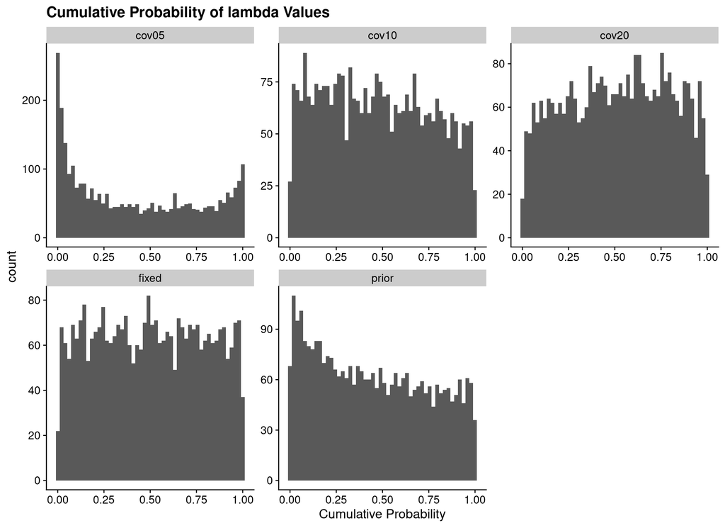

```r
calculate_posterior_data_probs <- customer_basic_simparams_tbl %>%
  construct_posterior_ecdf_function()

posterior_uniformcheck_tbl <- list(
    fixed = customer_basic_pnbd_fixed_posterior_tbl,
    prior = customer_basic_pnbd_prior_posterior_tbl,
    cov05 = post05_customer_tbl,
    cov10 = post10_customer_tbl,
    cov20 = post20_customer_tbl
    ) %>%
  enframe(name = "label", value = "post_data") %>%
  mutate(
    check_data = map(post_data, calculate_posterior_data_probs)
    )

plotdata_tbl <- posterior_uniformcheck_tbl %>%
  select(label, check_data) %>%
  unnest(check_data)

ggplot(plotdata_tbl) +
  geom_histogram(aes(x = post_lambda_qval), bins = 50) +
  facet_wrap(vars(label), scale = "free") +
  xlab("Cumulative Probability") +
  ggtitle("Cumulative Probability of lambda Values")
```

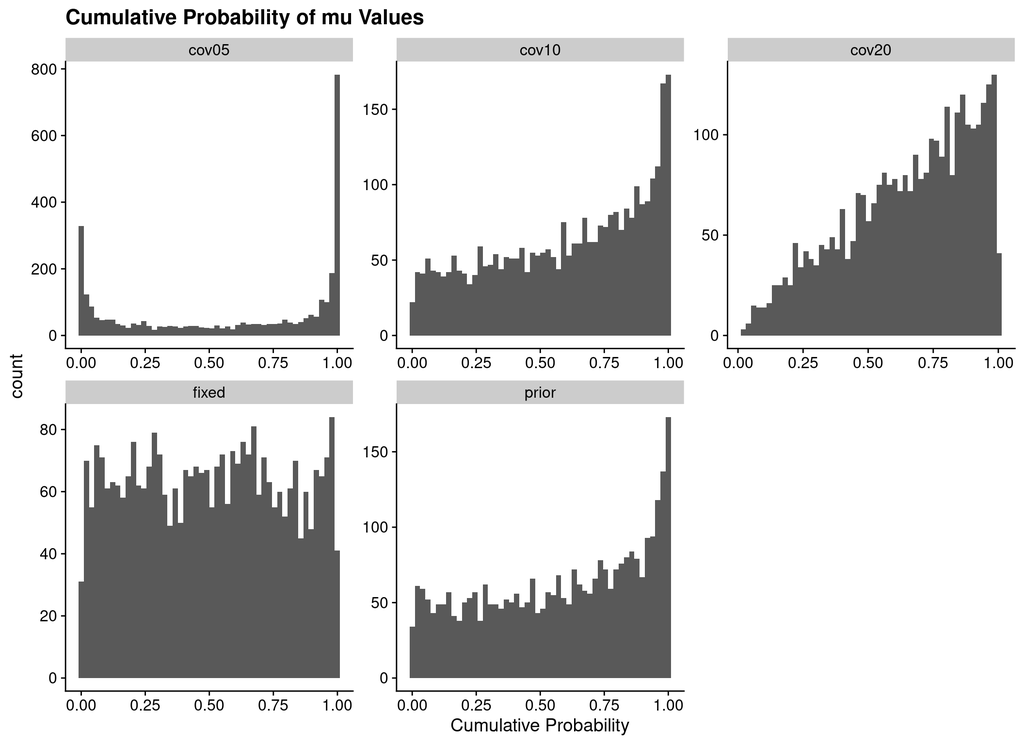

```r
ggplot(plotdata_tbl) +
  geom_histogram(aes(x = post_mu_qval), bins = 50) +
  facet_wrap(vars(label), scale = "free") +
  xlab("Cumulative Probability") +
  ggtitle("Cumulative Probability of mu Values")
```

# 4 Construct BG/NBD Models

## 4.1 Construct Fixed Hyper-parameter Model

```r
bgnbd_basic_fixed_stanmodel <- cmdstan_model(
  "stan_code/clv_bgnbd_fixed.stan",
  include_paths = "stan_code/",
  pedantic      =  TRUE,
  dir           = "stan_models/"
  )
```

```r
stan_data_lst <- customer_basic_cbs_tbl %>%
  select(-first_tnx_date, -last_tnx_date) %>%
  compose_data(
    r     =  1,
    alpha =  5,

    a     =  1,
    b     =  1,
    )

bgnbd_basic_fixed_stanfit <- bgnbd_basic_fixed_stanmodel$sample(
  data          =  stan_data_lst,
  chains        =              4,
  iter_warmup   =           1000,
  iter_sampling =           1000,
  seed          =            427
  )
```

```
## Running MCMC with 4 parallel chains...
##
## Chain 1 Iteration:    1 / 2000 [  0%]  (Warmup)
## Chain 2 Iteration:    1 / 2000 [  0%]  (Warmup)
## Chain 3 Iteration:    1 / 2000 [  0%]  (Warmup)
## Chain 4 Iteration:    1 / 2000 [  0%]  (Warmup)
## Chain 2 Iteration:  100 / 2000 [  5%]  (Warmup)
## Chain 4 Iteration:  100 / 2000 [  5%]  (Warmup)
## Chain 3 Iteration:  100 / 2000 [  5%]  (Warmup)
## Chain 1 Iteration:  100 / 2000 [  5%]  (Warmup)
## Chain 2 Iteration:  200 / 2000 [ 10%]  (Warmup)
## Chain 4 Iteration:  200 / 2000 [ 10%]  (Warmup)
## Chain 3 Iteration:  200 / 2000 [ 10%]  (Warmup)
## Chain 1 Iteration:  200 / 2000 [ 10%]  (Warmup)
## Chain 2 Iteration:  300 / 2000 [ 15%]  (Warmup)
## Chain 4 Iteration:  300 / 2000 [ 15%]  (Warmup)
## Chain 3 Iteration:  300 / 2000 [ 15%]  (Warmup)
## Chain 1 Iteration:  300 / 2000 [ 15%]  (Warmup)
## Chain 2 Iteration:  400 / 2000 [ 20%]  (Warmup)
## Chain 4 Iteration:  400 / 2000 [ 20%]  (Warmup)
## Chain 3 Iteration:  400 / 2000 [ 20%]  (Warmup)
## Chain 1 Iteration:  400 / 2000 [ 20%]  (Warmup)
## Chain 2 Iteration:  500 / 2000 [ 25%]  (Warmup)
## Chain 4 Iteration:  500 / 2000 [ 25%]  (Warmup)
## Chain 3 Iteration:  500 / 2000 [ 25%]  (Warmup)
## Chain 1 Iteration:  500 / 2000 [ 25%]  (Warmup)
## Chain 2 Iteration:  600 / 2000 [ 30%]  (Warmup)
## Chain 4 Iteration:  600 / 2000 [ 30%]  (Warmup)
## Chain 3 Iteration:  600 / 2000 [ 30%]  (Warmup)
## Chain 1 Iteration:  600 / 2000 [ 30%]  (Warmup)
## Chain 2 Iteration:  700 / 2000 [ 35%]  (Warmup)
## Chain 4 Iteration:  700 / 2000 [ 35%]  (Warmup)
## Chain 3 Iteration:  700 / 2000 [ 35%]  (Warmup)
## Chain 1 Iteration:  700 / 2000 [ 35%]  (Warmup)
## Chain 2 Iteration:  800 / 2000 [ 40%]  (Warmup)
## Chain 4 Iteration:  800 / 2000 [ 40%]  (Warmup)
## Chain 3 Iteration:  800 / 2000 [ 40%]  (Warmup)
## Chain 1 Iteration:  800 / 2000 [ 40%]  (Warmup)
## Chain 2 Iteration:  900 / 2000 [ 45%]  (Warmup)
## Chain 4 Iteration:  900 / 2000 [ 45%]  (Warmup)
```

[output cut: 43 more lines]

```
## Chain 3 Iteration: 1900 / 2000 [ 95%]  (Sampling)
## Chain 4 Iteration: 1900 / 2000 [ 95%]  (Sampling)
## Chain 1 Iteration: 1900 / 2000 [ 95%]  (Sampling)
## Chain 2 Iteration: 2000 / 2000 [100%]  (Sampling)
## Chain 2 finished in 213.3 seconds.
## Chain 3 Iteration: 2000 / 2000 [100%]  (Sampling)
## Chain 4 Iteration: 2000 / 2000 [100%]  (Sampling)
## Chain 3 finished in 214.1 seconds.
## Chain 4 finished in 213.8 seconds.
## Chain 1 Iteration: 2000 / 2000 [100%]  (Sampling)
## Chain 1 finished in 216.8 seconds.
##
## All 4 chains finished successfully.
## Mean chain execution time: 214.5 seconds.
## Total execution time: 217.1 seconds.
```

We first want to check the HMC diagnostics.

```r
bgnbd_basic_fixed_stanfit$cmdstan_diagnose()
```

```
## Processing csv files: /tmp/Rtmpej5ofO/clv_bgnbd_fixed-202112141626-1-2c780d.csv, /tmp/Rtmpej5ofO/clv_bgnbd_fixed-202112141626-2-2c780d.csv, /tmp/Rtmpej5ofO/clv_bgnbd_fixed-202112141626-3-2c780d.csv, /tmp/Rtmpej5ofO/clv_bgnbd_fixed-202112141626-4-2c780d.csv
##
## Checking sampler transitions treedepth.
## Treedepth satisfactory for all transitions.
##
## Checking sampler transitions for divergences.
## No divergent transitions found.
##
## Checking E-BFMI - sampler transitions HMC potential energy.
## E-BFMI satisfactory.
##
## Effective sample size satisfactory.
##
## Split R-hat values satisfactory all parameters.
##
## Processing complete, no problems detected.
```

```r
bgnbd_basic_fixed_stanfit$save_output_files(
  dir      = "stan_models",
  basename = "bgnbd_basic_fixed"
  )
```

# 5 R Environment

```r
options(width = 120L)
```

```r
options(width = 80L)
```